# Desafio 11

Author

Luiz Fernando de Oliveira Pereira RA:267356

## Quarto

```python
import polars as pl
```

1. Utilizando o arquivo `renda_adulta.csv` e sabendo que ele não possui cabeçalho, faça a importação do banco de dados utilizando os nomes das colunas conforme apresentado acima e na sequência ali indicada. No momento da importação do arquivo, você deve, também, indicar os tipos de cada uma das colunas. Utilize o fato de que o símbolo `?` representa valores faltantes.

```python
# Definindo os nomes de cada coluna
nomes_colunas = [
    "age", "workclass", "fnlwgt", "education", "education_num",
    "marital_status", "occupation", "relationship", "race", "sex",
    "capital_gain", "capital_loss", "hours_per_week", "native_country", "income"
]
```

```python
#Definindo o o que cada coluna é, seu tipo

tipos_colunas = {
    "age": pl.Int64,
    "workclass": pl.Utf8,
    "fnlwgt": pl.Int64,
    "education": pl.Utf8,
    "education_num": pl.Int64,
    "marital_status": pl.Utf8,
    "occupation": pl.Utf8,
    "relationship": pl.Utf8,
    "race": pl.Utf8,
    "sex": pl.Utf8,
    "capital_gain": pl.Int64,
    "capital_loss": pl.Int64,
    "hours_per_week": pl.Int64,
    "native_country": pl.Utf8,
    "income": pl.Utf8
}
```

```python
#Importando o banco de dados e colocando o cabeçalho nele

renda_adulta = pl.read_csv(
    "renda_adulta.csv",
    has_header=False, # = False, pois não tejm cabeçalho
    new_columns=nomes_colunas,
    dtypes=tipos_colunas,
    null_values="?"
)
```

```python
#Dando uma espiada nos dados
renda_adulta.head(10)
```

shape: (10, 15)

| age i64 | workclass str | fnlwgt i64 | education str | education_num i64 | marital_status str | occupation str | relationship str | race str | sex str | capital_gain i64 | capital_loss i64 | hours_per_week i64 | native_country str | income str |
| --- | --- | --- | --- | --- | --- | --- | --- | --- | --- | --- | --- | --- | --- | --- |
| 39 | "State-gov" | 77516 | "Bachelors" | 13 | "Never-married" | "Adm-clerical" | "Not-in-family" | "White" | "Male" | 2174 | 0 | 40 | "United-States" | "<=50K" |
| 50 | "Self-emp-not-inc" | 83311 | "Bachelors" | 13 | "Married-civ-spouse" | "Exec-managerial" | "Husband" | "White" | "Male" | 0 | 0 | 13 | "United-States" | "<=50K" |
| 38 | "Private" | 215646 | "HS-grad" | 9 | "Divorced" | "Handlers-cleaners" | "Not-in-family" | "White" | "Male" | 0 | 0 | 40 | "United-States" | "<=50K" |
| 53 | "Private" | 234721 | "11th" | 7 | "Married-civ-spouse" | "Handlers-cleaners" | "Husband" | "Black" | "Male" | 0 | 0 | 40 | "United-States" | "<=50K" |
| 28 | "Private" | 338409 | "Bachelors" | 13 | "Married-civ-spouse" | "Prof-specialty" | "Wife" | "Black" | "Female" | 0 | 0 | 40 | "Cuba" | "<=50K" |
| 37 | "Private" | 284582 | "Masters" | 14 | "Married-civ-spouse" | "Exec-managerial" | "Wife" | "White" | "Female" | 0 | 0 | 40 | "United-States" | "<=50K" |
| 49 | "Private" | 160187 | "9th" | 5 | "Married-spouse-absent" | "Other-service" | "Not-in-family" | "Black" | "Female" | 0 | 0 | 16 | "Jamaica" | "<=50K" |
| 52 | "Self-emp-not-inc" | 209642 | "HS-grad" | 9 | "Married-civ-spouse" | "Exec-managerial" | "Husband" | "White" | "Male" | 0 | 0 | 45 | "United-States" | ">50K" |
| 31 | "Private" | 45781 | "Masters" | 14 | "Never-married" | "Prof-specialty" | "Not-in-family" | "White" | "Female" | 14084 | 0 | 50 | "United-States" | ">50K" |
| 42 | "Private" | 159449 | "Bachelors" | 13 | "Married-civ-spouse" | "Exec-managerial" | "Husband" | "White" | "Male" | 5178 | 0 | 40 | "United-States" | ">50K" |

2. Apresente os tipos de cada uma das coluna.

```python
# Apresentando os tipos de cada coluna
renda_adulta.schema
```

```
Schema({'age': Int64, 'workclass': String, 'fnlwgt': Int64, 'education': String, 'education_num': Int64, 'marital_status': String, 'occupation': String, 'relationship': String, 'race': String, 'sex': String, 'capital_gain': Int64, 'capital_loss': Int64, 'hours_per_week': Int64, 'native_country': Str…
```

3. Apresente as dimensões da tabela de dados.

```python
# Apresentando as dimensões da tabela de dados
renda_adulta.shape
```

```
(32561, 15)
```

4. Quantas pessoas recebem acima de $50.000 e quantas pessoas recebem abaixo deste limiar?

```python
# Contando e separando em dois grupos
renda_adulta.group_by("income").count()
```

shape: (2, 2)

| income str | count u32 |
| --- | --- |
| ">50K" | 7841 |
| "<=50K" | 24720 |

5. Crie um objeto chamado `renda_longo`, no qual você transforma as colunas `capital-gain` e `capital-loss` (formato *wide*) para formato longo. Os valores destas variáveis devem ser armazenados numa nova coluna chamada `Valor` e os tipos de valores (*gain* e *loss*) devem ser armazenados numa coluna chamada `tipo`.

```python
# Criando o dataset no formato longo
renda_longo = renda_adulta.unpivot(
    index=[
        "age", "workclass", "fnlwgt", "education", "education_num",
        "marital_status", "occupation", "relationship", "race", "sex",
        "hours_per_week", "native_country", "income"
    ],
    on=["capital_gain", "capital_loss"],
    variable_name="tipo",
    value_name="Valor"
)

# Visualizando as primeiras linhas do novo formato
renda_longo.head(10)
```

shape: (10, 15)

| age i64 | workclass str | fnlwgt i64 | education str | education_num i64 | marital_status str | occupation str | relationship str | race str | sex str | hours_per_week i64 | native_country str | income str | tipo str | Valor i64 |
| --- | --- | --- | --- | --- | --- | --- | --- | --- | --- | --- | --- | --- | --- | --- |
| 39 | "State-gov" | 77516 | "Bachelors" | 13 | "Never-married" | "Adm-clerical" | "Not-in-family" | "White" | "Male" | 40 | "United-States" | "<=50K" | "capital_gain" | 2174 |
| 50 | "Self-emp-not-inc" | 83311 | "Bachelors" | 13 | "Married-civ-spouse" | "Exec-managerial" | "Husband" | "White" | "Male" | 13 | "United-States" | "<=50K" | "capital_gain" | 0 |
| 38 | "Private" | 215646 | "HS-grad" | 9 | "Divorced" | "Handlers-cleaners" | "Not-in-family" | "White" | "Male" | 40 | "United-States" | "<=50K" | "capital_gain" | 0 |
| 53 | "Private" | 234721 | "11th" | 7 | "Married-civ-spouse" | "Handlers-cleaners" | "Husband" | "Black" | "Male" | 40 | "United-States" | "<=50K" | "capital_gain" | 0 |
| 28 | "Private" | 338409 | "Bachelors" | 13 | "Married-civ-spouse" | "Prof-specialty" | "Wife" | "Black" | "Female" | 40 | "Cuba" | "<=50K" | "capital_gain" | 0 |
| 37 | "Private" | 284582 | "Masters" | 14 | "Married-civ-spouse" | "Exec-managerial" | "Wife" | "White" | "Female" | 40 | "United-States" | "<=50K" | "capital_gain" | 0 |
| 49 | "Private" | 160187 | "9th" | 5 | "Married-spouse-absent" | "Other-service" | "Not-in-family" | "Black" | "Female" | 16 | "Jamaica" | "<=50K" | "capital_gain" | 0 |
| 52 | "Self-emp-not-inc" | 209642 | "HS-grad" | 9 | "Married-civ-spouse" | "Exec-managerial" | "Husband" | "White" | "Male" | 45 | "United-States" | ">50K" | "capital_gain" | 0 |
| 31 | "Private" | 45781 | "Masters" | 14 | "Never-married" | "Prof-specialty" | "Not-in-family" | "White" | "Female" | 50 | "United-States" | ">50K" | "capital_gain" | 14084 |
| 42 | "Private" | 159449 | "Bachelors" | 13 | "Married-civ-spouse" | "Exec-managerial" | "Husband" | "White" | "Male" | 40 | "United-States" | ">50K" | "capital_gain" | 5178 |

6. Quais são as médias de horas trabalhadas por classe salarial?

```python
# Calculando a média de horas trabalhadas por classe salarial
media_horas_por_renda = (
    renda_adulta
    .group_by("income")
    .agg(pl.col("hours_per_week").mean().alias("media_horas"))
)

media_horas_por_renda
```

shape: (2, 2)

| income str | media_horas f64 |
| --- | --- |
| ">50K" | 45.473026 |
| "<=50K" | 38.84021 |

7. Se cada linha representa uma pessoa, quantas pessoas foram amostradas em cada profissão?

```python
# Contar quantas pessoas há em cada profissão
pessoas_por_profissao = (
    renda_adulta
    .group_by("occupation")
    .count()
    .sort("count", descending=True)  # Ordena da profissão mais comum à menos
)
pessoas_por_profissao
```

shape: (15, 2)

| occupation str | count u32 |
| --- | --- |
| "Prof-specialty" | 4140 |
| "Craft-repair" | 4099 |
| "Exec-managerial" | 4066 |
| "Adm-clerical" | 3770 |
| "Sales" | 3650 |
| … | … |
| "Farming-fishing" | 994 |
| "Tech-support" | 928 |
| "Protective-serv" | 649 |
| "Priv-house-serv" | 149 |
| "Armed-Forces" | 9 |

8. Crie um gráfico de barras que apresente o número médio de horas trabalhadas semanalmente em função do nível salarial.

   ```r
   #Definindo o local do python que irei utilizar
   library(reticulate)
   use_python("C:/Program Files/Python312/python.exe", required = TRUE)
   ```

   ```python
   #importando a biblioteca
   import matplotlib.pyplot as plt
   ```

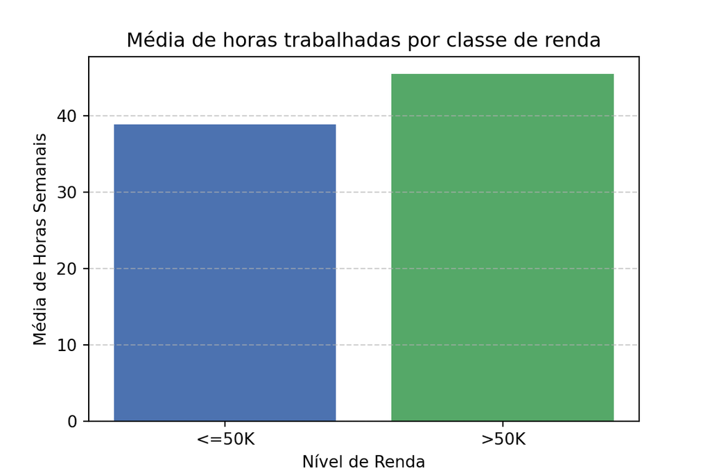

```python
# Agrupando os dados por 'income' e calcular a média de 'hours_per_week'
# pl.col("hours_per_week").mean() calcula a média das horas
# .alias("media_horas") renomeia a coluna de saída para 'media_horas'
media_horas_por_renda = (
    renda_adulta
    .group_by("income")              # Agrupa os registros por nível de renda
    .agg(pl.col("hours_per_week").mean().alias("media_horas"))
    .sort("income")                  # Ordena os resultados por renda para visualização
)

# Converter para pandas, porque matplotlib funciona melhor com pandas
media_horas_df = media_horas_por_renda.to_pandas()

# Criar gráfico de barras
plt.figure(figsize=(6,4))                                   # Define o tamanho da figura
plt.bar(
    media_horas_df["income"],                                # Eixo X: categorias de renda
    media_horas_df["media_horas"],                           # Eixo Y: média de horas
    color=["#4C72B0", "#55A868"]                             # Cores das barras
)
plt.xlabel("Nível de Renda")                                 # Legenda eixo X
plt.ylabel("Média de Horas Semanais")                       # Legenda eixo Y
plt.title("Média de horas trabalhadas por classe de renda") # Título do gráfico
plt.grid(axis='y', linestyle='--', alpha=0.6)               # Adiciona linhas de grade horizontais
plt.show()                                                   # Exibe o gráfico
```

9. **Desafio**: existe alguma evidência de discriminação salarial entre gêneros biológicos?

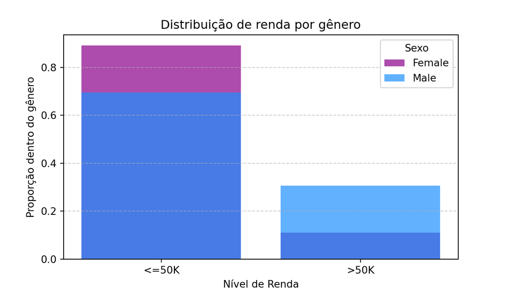

```python
# Agrupando por 'sex' e 'income', e contando o número de registros em cada combinação
# O .count() cria uma coluna com o número de pessoas
renda_por_genero = (
    renda_adulta
    .group_by(["sex", "income"])  # Agrupando por gênero e nível de renda
    .count()                      # Contando o número de pessoas em cada grupo
    .sort(["sex", "income"])      # Ordenando para facilitar a visualização
)
# Convertendo para pandas para facilitar manipulação e gráfico
renda_genero_df = renda_por_genero.to_pandas()

# Calculando a proporção de pessoas com cada nível de renda dentro de cada gênero
# .transform("sum") calcula o total de pessoas por gênero
total_por_genero = renda_genero_df.groupby("sex")["count"].transform("sum")
renda_genero_df["proporcao"] = renda_genero_df["count"] / total_por_genero

# Criar gráfico de barras lado a lado para comparar homens e mulheres
plt.figure(figsize=(7,4))

for sexo in renda_genero_df["sex"].unique():      # Para cada gênero
    dados = renda_genero_df[renda_genero_df["sex"] == sexo]  # Filtra os dados do gênero

     # Define cor personalizada
    if sexo.lower() == "male":
        cor = "#1E90FF"  # Azul pastel
    else:
        cor = "#8B008B"  # Vermelho pastel

    plt.bar(
        dados["income"],           # Eixo X: nível de renda
        dados["proporcao"],        # Eixo Y: proporção dentro do gênero
        alpha=0.7,                 # Transparência das barras
        label=sexo,                 # Nome do gênero para legenda
        color=cor                   # Definindo a cor
    )

plt.xlabel("Nível de Renda")                     # Legenda eixo X
plt.ylabel("Proporção dentro do gênero")        # Legenda eixo Y
plt.title("Distribuição de renda por gênero")   # Título do gráfico
plt.legend(title="Sexo")                         # Adiciona legenda com título
plt.grid(axis="y", linestyle="--", alpha=0.6)   # Linhas de grade horizontais
plt.show()                                      # Exibe o gráfico
```

```r
#Horário e dia em que o Html foi gerado
format(Sys.time(), "%d/%m/%Y %H:%M:%S")
```

```
[1] "07/10/2025 11:27:12"
```